[figure not shown]

# Kaggle Survey Machine Learning and Data Science 2017

https://www.kaggle.com/kaggle/kaggle-survey-2017

### Context

For the first time, Kaggle conducted an industry-wide survey to establish a comprehensive view of the state of data science and machine learning. The survey received over 16,000 responses and we learned a ton about who is working with data, what’s happening at the cutting edge of machine learning across industries, and how new data scientists can best break into the field.

I will perform exploratory analysis then explanatory analysis.

My questions are as follows:

1. Python or R?
2. What data science tools and methods are going be in the limelight?
3. Where should I learn Data Science?
4. Do I need a 'high-performance' computer to study Data Science?
5. How many hours should I study?
6. What blogs, Podcasts, classes are recommended for DS?
7. How much do data scientists make?
8. Where can I get data from?
9. How do data scientist spend most of their time at work?
10. What job skill is most important?

## Exploratory Analysis

### Gender

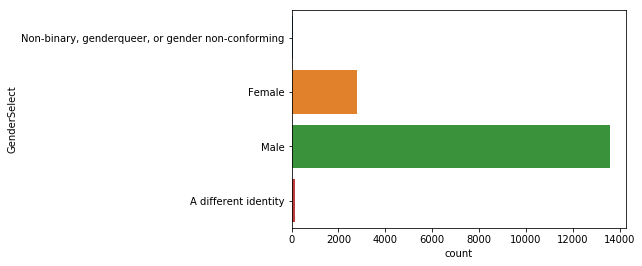

```python
sb.countplot(y='GenderSelect', data=mcq);
```

- The proportion of male is much higher than female and others

### Countries

```python
countries = pd.DataFrame(mcq.Country.value_counts())
countries
countries['Respond'] = countries.index
countries.columns = ['Count', 'Country']
countries = countries.reset_index().drop('index', axis=1)
#countries   # 52+ countries including Other (countries) in the 3rd place
countries.head(20)
```

|  | Count | Country |
| --- | --- | --- |
| 0 | 4197 | United States |
| 1 | 2704 | India |
| 2 | 1023 | Other |
| 3 | 578 | Russia |
| 4 | 535 | United Kingdom |
| 5 | 471 | People 's Republic of China |
| 6 | 465 | Brazil |
| 7 | 460 | Germany |
| 8 | 442 | France |
| 9 | 440 | Canada |
| 10 | 421 | Australia |
| 11 | 320 | Spain |
| 12 | 277 | Japan |
| 13 | 254 | Taiwan |
| 14 | 238 | Italy |
| 15 | 205 | Netherlands |
| 16 | 196 | Ukraine |
| 17 | 194 | South Korea |
| 18 | 184 | Singapore |
| 19 | 184 | Poland |

### Age

```python
# Average Age
mcq.Age.describe()
```

```
count    16385.000000
mean        32.372841
std         10.473487
min          0.000000
25%         25.000000
50%         30.000000
75%         37.000000
max        100.000000
Name: Age, dtype: float64
```

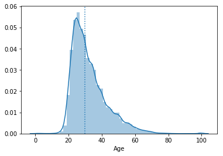

```python
# Using distplot for a univatiate distribution
sb.distplot(mcq[mcq['Age'] > 0]['Age'])
plt.axvline(mcq.Age.median(), linestyle=":");
```

- Most of survey participants are 20-30 years old
- The average age is 32

### Education

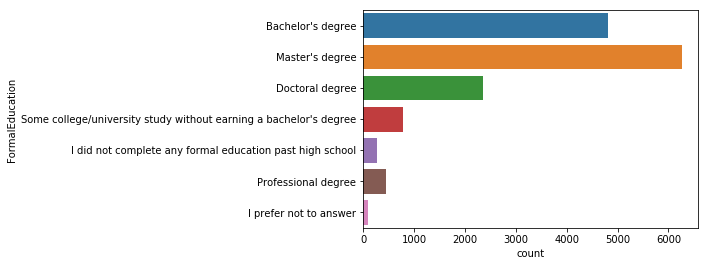

```python
sb.countplot(y='FormalEducation', data=mcq);
```

- Master's degree holders are more than Bachelor's degree holders
- Also, there are many participants with Doctoral degree as well

### Major

- Computer science is 33% of all participants
- Mathematics or Statistics, engineering, electrical engineering majors in that order

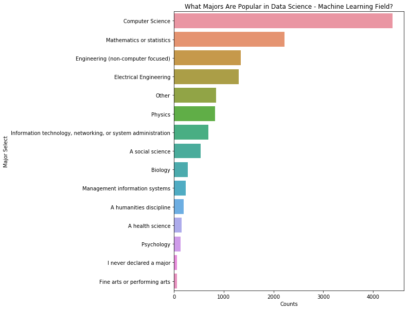

```python
plt.figure(figsize=(8,10))
sb.countplot(y='MajorSelect', data=mcq, order = mcq['MajorSelect'].value_counts().index)
plt.xlabel('Counts')
plt.ylabel('Major Select')
plt.title('What Majors Are Popular in Data Science - Machine Learning Field?');
```

### Employment Status

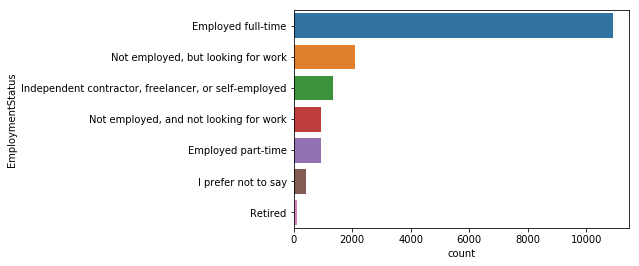

```python
sb.countplot(y='EmploymentStatus', data=mcq, order=mcq['EmploymentStatus'].value_counts().index);
```

- **65%** of 'Kagglers' are working full-time and **12%** are looking for job

### Programming Experience

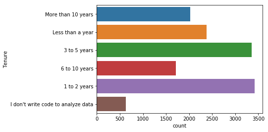

```python
sb.countplot(y='Tenure', data=mcq);
```

- Most people have 1 to 2 years and 3 to 5 year programming experience

```
The number of Kagglers(DS-ML) in USA is  4197
```

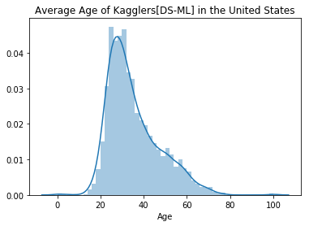

```python
usa = mcq[mcq['Country']=='United States']
sb.distplot(usa.Age.dropna())
print('The number of Kagglers(DS-ML) in USA is ', usa.shape[0])
plt.title('Average Age of Kagglers[DS-ML] in the United States');
```

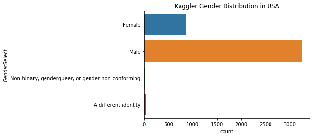

```python
usa_gender_prop = usa.GenderSelect.value_counts(normalize=True)
sb.countplot(y='GenderSelect', data=usa).set_title('Kaggler Gender Distribution in USA');
```

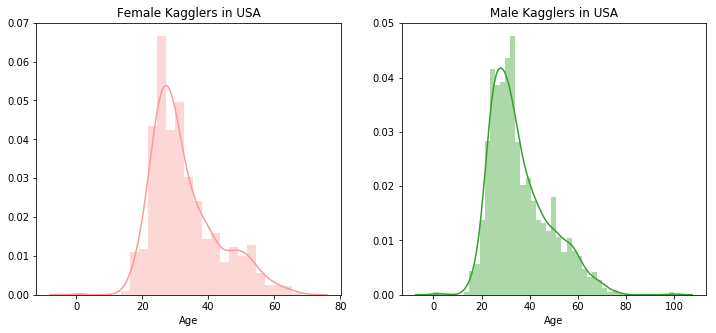

```python
figure, (ax1, ax2) = plt.subplots(ncols=2)

figure.set_size_inches(12,5)
sb.distplot(usa['Age'].loc[usa['GenderSelect']=='Female'].dropna(), norm_hist=False, color=sb.color_palette("Paired")[4], ax=ax1).set_title("Female Kagglers in USA")

sb.distplot(usa['Age'].loc[usa['GenderSelect']=='Male'].dropna(), norm_hist=False, color=sb.color_palette("Paired")[3], ax=ax2).set_title("Male Kagglers in USA");
```

- There are only 800+ female Kagglers in the United States, which means it's hard to generalize. However, a majority of female Kagglers are **24-32** years old while a majority of male Kaagglers are **22-36** years old

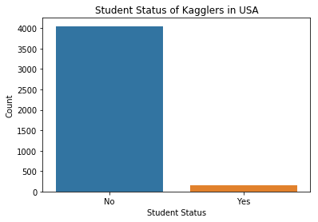

```python
usa['StudentStatus'] = usa['StudentStatus'].fillna('No')
sb.countplot(x='StudentStatus', data=usa)
plt.title('Student Status of Kagglers in USA');
plt.xlabel('Student Status')
plt.ylabel('Count');
```

## Explnatory Analysis

#### QUESTIONS:

1. Python or R?
2. What data science tools and methods are going be in the limelight?
3. Where should I learn Data Science?
4. Do I need a 'high-performance' computer to study Data Science?
5. How many hours should I study?
6. What blogs, Podcasts, classes are recommended for DS?
7. How much do data scientists make?
8. Where can I get data from?
9. How do data scientist spend most of their time at work?
10. What job skill is most important?

### 1. Python or R?

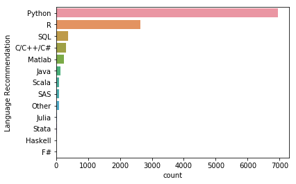

```python
sb.countplot(y='LanguageRecommendationSelect', data=mcq, order=mcq.LanguageRecommendationSelect.value_counts().index)
plt.ylabel('Language Recommendation');
```

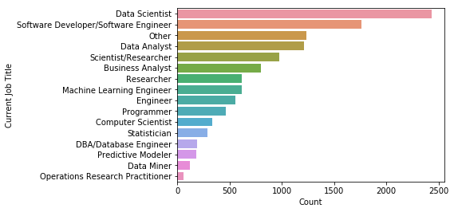

```python
sb.countplot(y=mcq.CurrentJobTitleSelect, order=mcq.CurrentJobTitleSelect.value_counts().index)
plt.xlabel('Count')
plt.ylabel('Current Job Title');
```

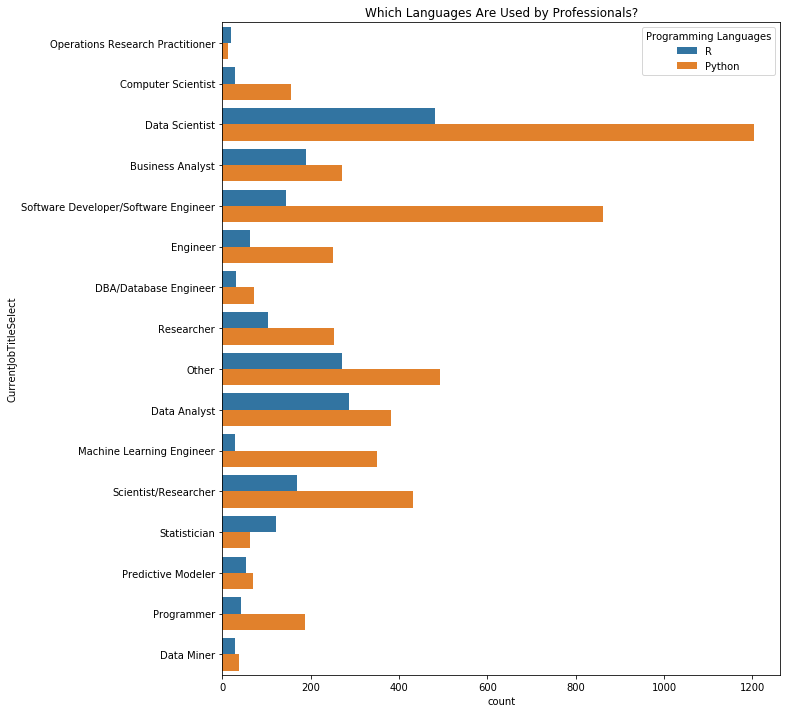

```python
plt.figure(figsize=(10,12))
sb.countplot(y='CurrentJobTitleSelect', hue='LanguageRecommendationSelect', data=py_r)
plt.title('Which Languages Are Used by Professionals?')
plt.legend(title="Programming Languages");
```

### 2. What Data Science Tools and Methods Are Going be in the Limelight?

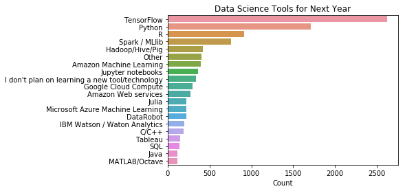

```python
ml_tool_data = mcq['MLToolNextYearSelect'].value_counts().head(20)
sb.barplot(y=ml_tool_data.index, x=ml_tool_data).set_title("Data Science Tools for Next Year")
plt.xlabel('Count');
```

- TensorFlow 23%, Python 15%, R 8%
- Clouds: Amazon ML, Google Cloud Computing, MS Azure ML, IMB Watson

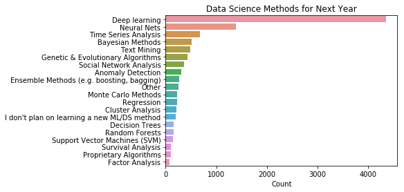

```python
ml_method_data = mcq['MLMethodNextYearSelect'].value_counts().head(20)
sb.barplot(y=ml_method_data.index, x=ml_method_data).set_title("Data Science Methods for Next Year")
plt.xlabel('Count');
```

- **Deep Learning, Neural Nets, Times Series Analysis, Baysean Methods** will be popular
- Actually, **all** these methods are very useful; so learn them all!

### 3. Where Should I Learn Data Science?

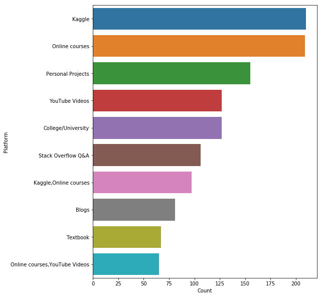

```python
plt.figure(figsize=(8,10))
data = s[s != 'nan'].value_counts().head(10)
sb.barplot(y=data.index, x=data)
plt.xlabel('Count')
plt.ylabel('Platform');
```

- People recommended Kaggle the most
- However, this survey was hosted in Kaggle; so the result might be biased

### 4. Do I Need a 'High-Performance' Computer to Study Data Science?

```python
a = a[a != 'nan']
pd.DataFrame(a.value_counts())
```

[output not shown]

- Macbook users, labto + Cloud service, Azure, and gaming labtop with capable GPU!

### 5. How Many Hours Should I Study?

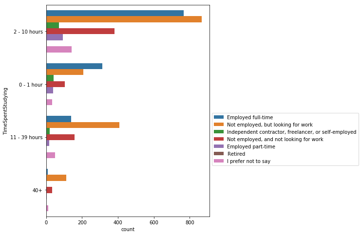

```python
plt.figure(figsize=(6,8))
sb.countplot(y='TimeSpentStudying', data=mcq, hue='EmploymentStatus').legend(loc='best', bbox_to_anchor=(1.0,0.5));
```

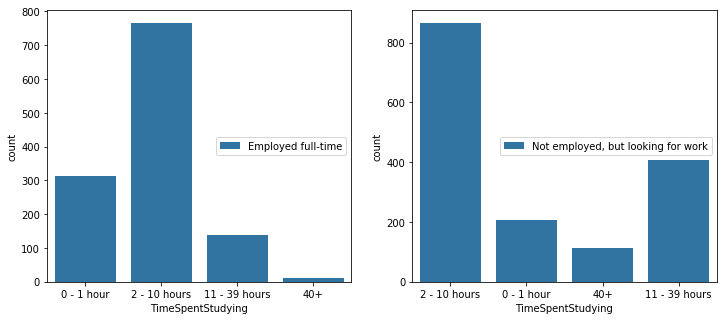

```python
figure, (ax1, ax2) = plt.subplots(ncols=2)
figure.set_size_inches(12,5)
full_time = mcq[mcq['EmploymentStatus']=='Employed full-time']
sb.countplot(x='TimeSpentStudying', data=full_time, hue='EmploymentStatus', ax=ax1).legend(loc='center right', bbox_to_anchor=(1,0.5))

job_seekers = mcq[mcq['EmploymentStatus']=='Not employed, but looking for work']
sb.countplot(x='TimeSpentStudying', data=job_seekers, hue='EmploymentStatus', ax=ax2).legend(loc='center right', bbox_to_anchor=(1,0.5));
```

### 6. What Blogs, Podcasts, Classes Are Recommended?

```python
plt.figure(figsize=(8,10))
plt.title('Most Popular Blogs, Podcasts and Newsletters')
plt.xlabel('Count')
plt.ylabel('Contents')
sb.barplot(y=data.index, x=data);
```

[output not shown]

```python
plt.title("Most Popular Courses")
sb.barplot(x = course.index, y=course)
plt.ylabel('Count');
```

[output not shown]

### 7. How Much Do Data Scientists Make?

- The maximum salary is fake data for sure, since it's higher than some countries GDP!
- We will need to search for the real maximum salary in the market and make it as the limit
- Or, we can set limit as $ 500,000 first to see how graph looks like

```python
plt.figure(figsize=(15,8))
plt.title('Salary Distribution of DS-ML Employees (in USD)')
plt.ylabel('Proportion')
salary = salary[salary['Salary'] < 500000]
sb.distplot(salary['Salary'])
plt.axvline(salary['Salary'].median(), linestyle=':');
```

[output not shown]

- The mean salary is $53812

```python
salary_country = salary.groupby('Country')['Salary'].mean().sort_values(ascending=False).to_frame()
plt.figure(figsize=(10,13))
plt.title('Average Salary of Data Scientist Around the World')
sb.barplot('Salary', salary_country.index, data=salary_country)
plt.axvline(salary['Salary'].median(), linestyle=(':'));
```

[output not shown]

- Data Scientists and Machine Learning Scientists in the United States make \$115,689 on average, which is more than twice of national mean $53,812

```python
plt.subplots(figsize=(8,6))
sb.boxplot(y='GenderSelect', x='Salary', data=salary);
```

[output not shown]

- There's no distinct gender salary gap. However, for those who make more than \$350,000, are all male scientists.

### 8. Where Can I Get Data From?

```python
plt.title("Most Popular Dataset Sources")
sb.barplot(y=sources.index, x=sources)
plt.xlabel("Count");
```

[output not shown]

- The most popular dataset source is Socrata, Kaggle, data.world, and google search followed

### 9. How Do Data Scientist Spend Most of Their Time at Work?

```python
plt.pie(t, labels=t.index, autopct='%1.1f%%')
plt.axis('equal')
plt.title("Percentage of Time Spent on Each Indivisual");
```

[output not shown]

- DS spend 37% of their time for **data gathering**. They also spend a lot of time to build models, create visualizations, and find insights.

### 10. What job skill is most important?

```python
# Create heatmap
plt.figure(figsize=(10,8))
plt.title('Important Skills in DS Careers')
sb.heatmap(job.sort_values('Necessary', ascending = False), annot=True);
```

[output not shown]

```python
job.plot(kind='bar', figsize=(15,10), title ='Important Skills in DS Careers')
plt.xlabel("Skill")
plt.ylabel("Proportion");
```

[output not shown]

- Python, statistics knowledge, skills in visualization, SQL, and R are very necessary
- MOOC, KaggleRanking, EnterpriseTools, Degree are nice to have (to find a job or develop careers)

#### References:

- https://seaborn.pydata.org/tutorial/distributions.html
- https://matplotlib.org/3.1.0/api/_as_gen/matplotlib.pyplot.boxplot.html
- https://matplotlib.org/3.1.0/gallery/pie_and_polar_charts/pie_features.html
- https://seaborn.pydata.org/tutorial/color_palettes.html
- https://seaborn.pydata.org/generated/seaborn.heatmap.html
- https://matplotlib.org/3.1.0/api/legend_api.html